# RNA-sequencing Analysis Tutorial

Salmon with DESeq2

Jillybeth Burgado

Last Updated: December 2021

# Introduction

The purpose of this tutorial is to go over how to import and summarize transcript-level abundance estimates and complete differential expression (DE) analysis using DESeq2. I also include some basic ideas for downstream analysis and visualizing your data. The original article describing these methods can be found below:

> Charlotte Soneson, Michael I. Love, Mark D. Robinson (2015): Differential analyses for RNA-seq: transcript-level estimates improve gene-level inferences. F1000Research http://dx.doi.org/10.12688/f1000research.7563.1

**Notes**

- If you are primarily interested in how to use DESeq2 or visualizations of RNA-seq results, skip to Part 2: Differential Expression Analysis using DESeq2.
- Another Bioconductor package, tximeta (Love et al. 2020), extends tximport, offering the same functionality, plus the additional benefit of automatic addition of annotation metadata for commonly used transcriptomes (GENCODE, Ensembl, RefSeq for human and mouse). tximeta also offers easy conversion to data objects used by edgeR and limma with the makeDGEList function.

# Installing and Loading packages

The first step is to install and load required packages. Visit https://www.datacamp.com/community/tutorials/r-packages-guide for more information about packages and package repositories. You only need to install packages once - however, you need to keep track of versions and you may need to update packages depending on new releases. Below is an example of how to install a package from the Bioconductor repo.

```r
#install packages
if (!requireNamespace("BiocManager", quietly = FALSE))
  install.packages("BiocManager")
install.packages("pheatmap")
BiocManager::install("tximport")
```

```r
#load necessary packages
library(tidyr)
library(tximport)
library(AnnotationDbi)
library(TxDb.Mmusculus.UCSC.mm10.knownGene)
library(DESeq2)
library(biomaRt)
library(pheatmap)
library(enrichplot)
library(clusterProfiler)
library(ggplot2)
library(dplyr)
library(RColorBrewer)
library(EnhancedVolcano)
library(gridExtra)
library(egg)
library(ReportingTools)
library(regionReport)
library(DT)
library(reshape)
library(org.Mm.eg.db)
library(usethis)
```

# Transcript quantification for gene-level analysis

You will need a metadata file that includes your sample names as well as any group/explanatory variables. Your sample names need to exactly match your file names (from Salmon), 1 sample per row. I recommend exporting the names.txt file you created when doing the Salmon analysis on the Linux server.

```r
metadata <- read.csv("MattAgingAstrocyte_Metadata2.csv", header = TRUE)
```

## Create an annotation file

This file (called *tx2gene*) will allow you to convert your transcript IDs to gene IDs for gene-level analysis. This file needs the transcript IDs in the first column and the gene IDs in the second column. The *GENEID* is the Entrez Gene IDs

```r
txdb <- TxDb.Mmusculus.UCSC.mm10.knownGene
columns(txdb) ## How to see the names of the columns in your database. Can be helpful for picking your keytype
```

```
##  [1] "CDSCHROM"   "CDSEND"     "CDSID"      "CDSNAME"    "CDSPHASE"
##  [6] "CDSSTART"   "CDSSTRAND"  "EXONCHROM"  "EXONEND"    "EXONID"
## [11] "EXONNAME"   "EXONRANK"   "EXONSTART"  "EXONSTRAND" "GENEID"
## [16] "TXCHROM"    "TXEND"      "TXID"       "TXNAME"     "TXSTART"
## [21] "TXSTRAND"   "TXTYPE"
```

```r
k <- keys(txdb, keytype = "TXNAME")
tx2gene <- AnnotationDbi::select(txdb, k, "GENEID", "TXNAME")
#omit NAs
tx2gene_clean <- na.omit(tx2gene)
#Remove the transcript version - this may not be needed, but sometimes they don't match across databases
tx2gene_clean$TXNAME <- gsub("\\..*[0-9]", "", tx2gene_clean$TXNAME)
```

## Import and Summarize transcript quantification files

The tximport package has a single function for importing transcript-level estimates. The type argument is used to specify what software was used for estimation. A simple list with matrices, “abundance”, “counts”, and “length”, is returned, where the transcript level information is summarized to the gene-level. Typically, abundance is provided by the quantification tools as TPM (transcripts-per-million), while the counts are estimated counts (possibly fractional), and the “length” matrix contains the effective gene lengths.

```r
#file path for tximport
files <- file.path("aging_out", metadata$FullSampleName, "quant.sf")
names(files) <- metadata$FullSampleName
all(file.exists(files))
```

```
## [1] TRUE
```

```r
txi <- tximport(files, type = "salmon", tx2gene = tx2gene_clean, ignoreTxVersion = TRUE)
```

```
## reading in files with read_tsv
```

```
## 1 2 3 4 5 6 7 8 9 10 11 12 13 14 15 16 17 18 19 20 21 22 23 24 25 26 27 28 29 30
## transcripts missing from tx2gene: 21220
## summarizing abundance
## summarizing counts
## summarizing length
```

## Create tpm table

```r
#matrix with tpm values
tpm <- txi$abundance

#convert gene ids to gene names and other annotations
mart <- biomaRt::useDataset("mmusculus_gene_ensembl", useMart("ensembl")) #for default mouse genome

gene_list <- getBM(filters= "entrezgene_id",
                   attributes=c("entrezgene_id","mgi_symbol","description","ensembl_gene_id","ensembl_transcript_id"),
                   values= rownames(tpm),
                   mart= mart,
                   useCache = FALSE)

gene_list <- gene_list[!duplicated(gene_list$entrezgene_id),] #remove duplicates

#listAttributes(mart) ##run this line to see the available options for attributes/annotations

tpm <- merge(tpm, gene_list, by.x = 0,by.y = c("entrezgene_id"),all = TRUE)

tpm <- rename(tpm, EntrezGene_ID = Row.names)

#write.csv (tpm, "MattAgingAstrocyte_TPM.csv", row.names = FALSE)
```

## Plot Histogram of tpm values

This can be helpful for determining a TPM cutoff for expression

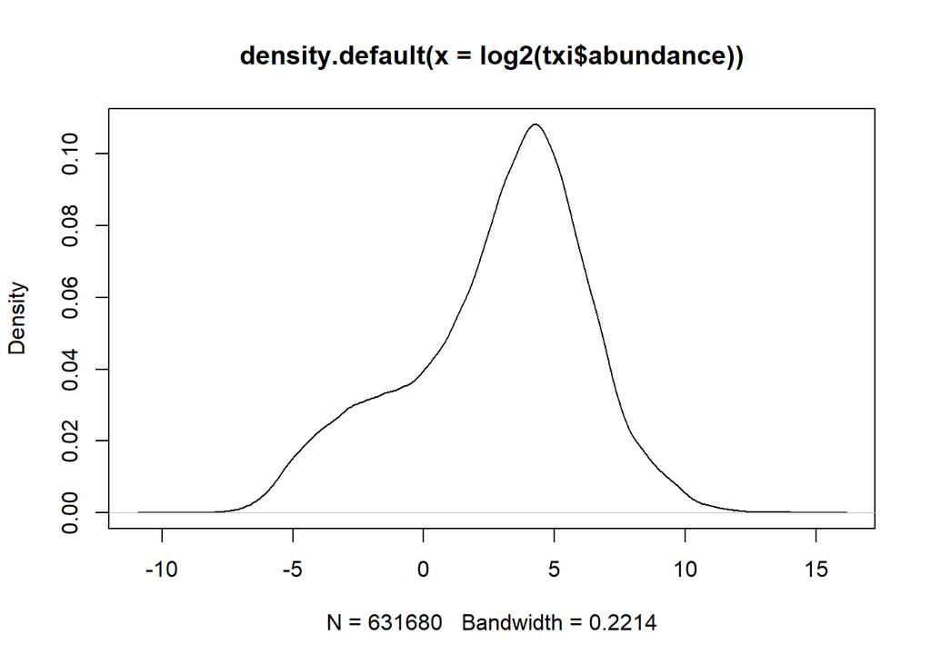

```r
plot(density(log2(txi$abundance)))
```

# Differential Expression Analysis using DESeq2

Check out [this tutorial](http://bioconductor.org/packages/release/bioc/vignettes/DESeq2/inst/doc/DESeq2.html) for detailed information regarding the DESeq2 package.

DESeq2 takes in a counts matrix - the number of sequence fragments that have been assigned to each gene. To statistical determine which genes are differentially expressed genes, we need to determine the changes between our conditions compared to the within-condition variability. DESeq2 uses a negative binomial generalized linear model. The normalized counts provided by DESeq2 are called *median of ratios*. You should not use these normalized counts for within sample comparison - They are primarily used for DE analysis.

First you create a DESeqDataSet (dds) and then run DE analysis. In my example data, astrocyte mRNA was sequenced from 4-month and 2-year old male mice, from 5 different brain regions, using the Ribotag system [original paper](https://www.ncbi.nlm.nih.gov/pmc/articles/PMC5783200/).

**Note** Check out the tutorial above for information regarding multiple conditions and interaction terms. In this case, I would actually make a new variable combining age and region, to keep things simple. Then I would use that new variable in my design (instead of *Age* as shown below; see the 2nd code chunk for how to do this).

```r
dds <- DESeqDataSetFromTximport(txi, metadata, ~Age) #the ~ are your design variables. If you would like to test for an interaction you would do ~Age + RealRegion + Age:RealRegion

dds$Age <- relevel(dds$Age, ref = "4m") #Set a group as reference; default is alphabetical

dge <- DESeq(dds) #run Diff gene exp analysis

round(colSums(counts(dds))/1e6) #number of reads per sample


#Code if counts matrix (i.e. from STAR) is the input instead of txi from Salmon
dds <- DESeqDataSetFromMatrix(countData = counts,
                              colData = metadata,
                              design = ~ Group)
```

```r
metadata$AgeRegion <- as.character(paste(metadata$Age, metadata$RealRegion, sep= "_"))
dds <- DESeqDataSetFromTximport(txi, metadata, ~AgeRegion)
```

```
## using counts and average transcript lengths from tximport
```

```r
dge <- DESeq(dds)
```

```
## using 'avgTxLength' from assays(dds), correcting for library size
```

## Extracting Results from DE Analysis

```r
resultsNames(dge) #view names for the different combinations you tested for - but only for the ones against reference level. Since we have multiple groups (and no single baseline/control), use the contrast option (2nd option below)
```

```
##  [1] "Intercept"                 "AgeRegion_2y_HTH_vs_2y_CB"
##  [3] "AgeRegion_2y_MC_vs_2y_CB"  "AgeRegion_2y_SSC_vs_2y_CB"
##  [5] "AgeRegion_2y_VC_vs_2y_CB"  "AgeRegion_4m_CB_vs_2y_CB"
##  [7] "AgeRegion_4m_HTH_vs_2y_CB" "AgeRegion_4m_MC_vs_2y_CB"
##  [9] "AgeRegion_4m_SSC_vs_2y_CB" "AgeRegion_4m_VC_vs_2y_CB"
```

```r
summary(results(dge, name = "AgeRegion_4m_VC_vs_2y_CB")) #this option won't give you all of your possible comparisons, just those against your reference level
```

```
##
## out of 18212 with nonzero total read count
## adjusted p-value < 0.1
## LFC > 0 (up)       : 3799, 21%
## LFC < 0 (down)     : 3857, 21%
## outliers [1]       : 5, 0.027%
## low counts [2]     : 2452, 13%
## (mean count < 1)
## [1] see 'cooksCutoff' argument of ?results
## [2] see 'independentFiltering' argument of ?results
```

```r
summary(results(dge, contrast =c("AgeRegion", "2y_VC","4m_VC"))) #use this to obtain all possible comparisons
```

```
##
## out of 18212 with nonzero total read count
## adjusted p-value < 0.1
## LFC > 0 (up)       : 179, 0.98%
## LFC < 0 (down)     : 158, 0.87%
## outliers [1]       : 5, 0.027%
## low counts [2]     : 3152, 17%
## (mean count < 3)
## [1] see 'cooksCutoff' argument of ?results
## [2] see 'independentFiltering' argument of ?results
```

```r
res_VC <- results(dge, contrast =c("AgeRegion", "2y_VC","4m_VC")) #select results as table, needed for visualizations below
res_MC <- results(dge, contrast =c("AgeRegion", "2y_MC","4m_MC"))
res_HTH <- results(dge, contrast =c("AgeRegion", "2y_HTH","4m_HTH"))
res_SSC <- results(dge, contrast =c("AgeRegion", "2y_SSC","4m_SSC"))
res_CB <- results(dge, contrast =c("AgeRegion", "2y_CB","4m_CB"))

#make dataframes of all contrasts
res_VC.df <- as.data.frame(res_VC)
res_MC.df <- as.data.frame(res_MC)
res_CB.df <- as.data.frame(res_CB)
res_HTH.df <- as.data.frame(res_HTH)
res_SSC.df <- as.data.frame(res_SSC)

#write.csv(res_VC.df, "AgingAstroTranscriptome_Results_VC.csv", row.names = TRUE) #to export as csv file
```

## Visualizations

### MA Plot

the function plotMA shows the log2 fold changes attributable to a given variable over the mean of normalized counts for all the samples in the DESeqDataSet.

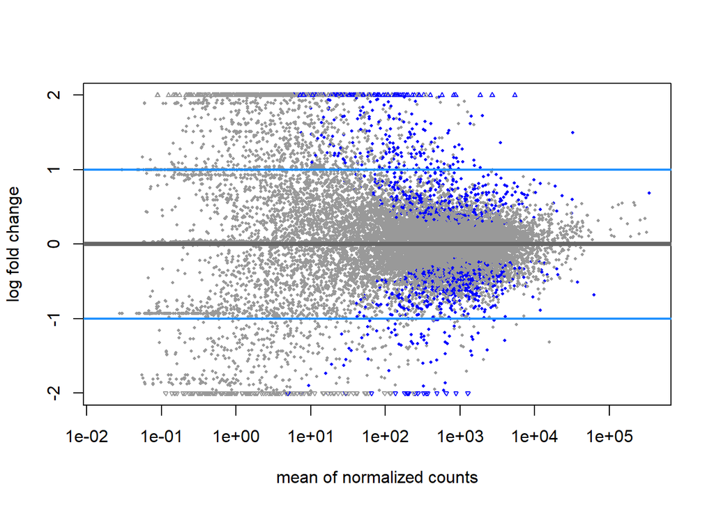

```r
plotMA(res_CB, ylim=c(-2,2))
abline(h=c(-1,1), col="dodgerblue", lwd=2) #add horizontal line
```

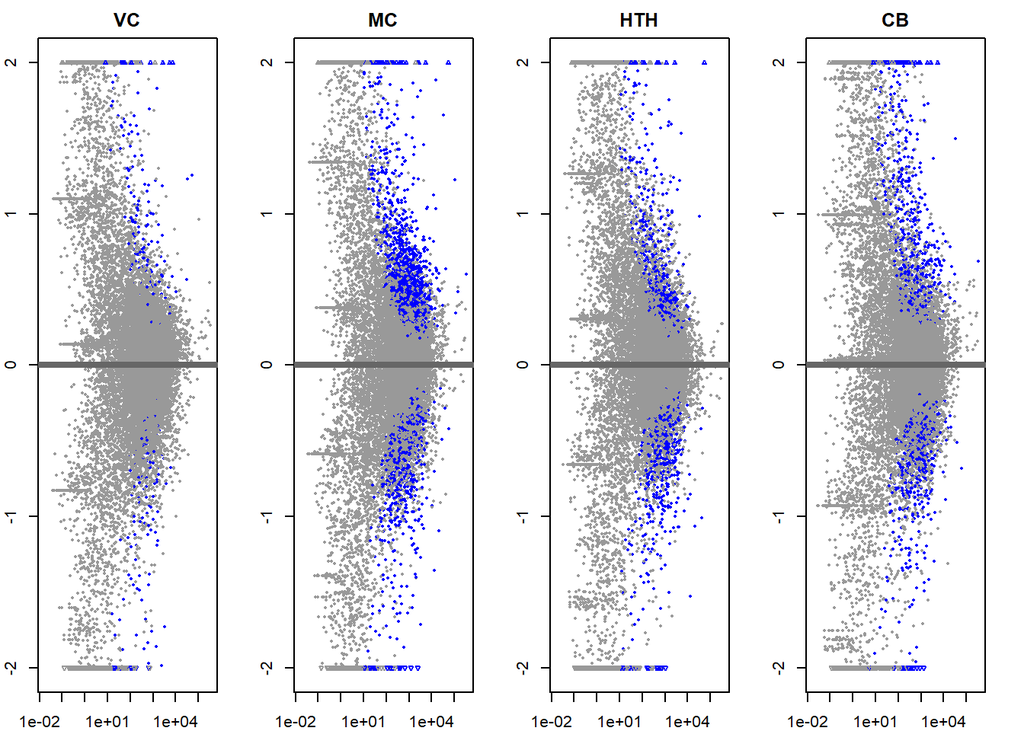

```r
par(mfrow=c(1,4), mar=c(2,2,2,2))
plotMA(res_VC, ylim=c(-2,2), main = "VC")
plotMA(res_MC, ylim=c(-2,2), main = "MC")
plotMA(res_HTH, ylim=c(-2,2), main = "HTH")
plotMA(res_CB, ylim=c(-2,2), main = "CB")
```

### PCA

There are several different options for making PCA plots in R. Here I show an example with plotPCA and ggplot. The other popular option is [PCAtools](https://bioconductor.org/packages/devel/bioc/vignettes/PCAtools/inst/doc/PCAtools.html)

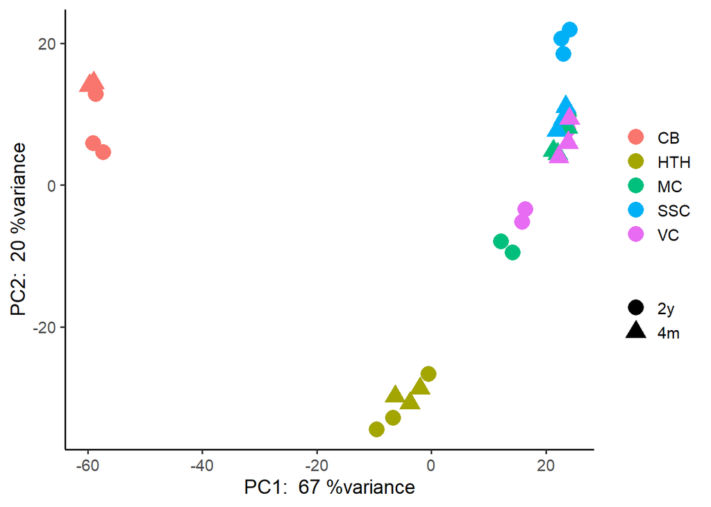

```r
vsd <- vst(dge) #1st you need to transform data. I use variance stabilization transformation

data <- plotPCA(vsd, intgroup = "Age", returnData = TRUE)

percent_var <- round(100 * attr(data, "percentVar"))

ggplot(data, aes(x = PC1, y = PC2, color = metadata$RealRegion, shape = metadata$Age)) +
  geom_point(size = 5) +
  xlab(paste("PC1: ", percent_var[1], "%variance")) +
  ylab(paste("PC2: ", percent_var[2], "%variance")) +
  theme_classic(base_size = 14) + theme(legend.title = element_blank())
```

Here is another PCA plot, but with a few more modifications. The commented lines are not included in the code to generate the plot (included here as an example, if you wanted to add labels to each point).

```r
pca <- ggplot(data, aes(x = PC1, y = PC2,
                        color = metadata$Age, shape = metadata$RealRegion))+
      geom_point(size = 3) +
      # geom_text_repel(aes(label = 'labelname',
      #                 nudge_x = .5, nudge_y = 0.5,
      #                 fontface = 2,
      #                 check_overlap = TRUE,
      #                 size = 4) +
      xlab(paste("PC1: ", percent_var[1], "%variance")) +
      ylab(paste("PC2: ", percent_var[2], "%variance")) +
      labs(shape = "Brain Region", color = "Age") +
      scale_shape_discrete(labels=c("Cerebellum", "Hypothalamus", "Motor Cortex", "Somatosensory", "Visual Cortex")) +
      scale_color_discrete(labels=c("2 year old", "4 month old")) +
      scale_color_manual(values = c("deeppink1","deepskyblue1"))+
      theme_classic(base_size = 12)  +
      theme(plot.title = element_text(hjust = 0.5, size=14, face="bold", margin = margin(0,0,10,0))) +
      ggtitle("PCA: Aging Astrocyte Transcriptome")
```

```
## which will replace the existing scale.
```

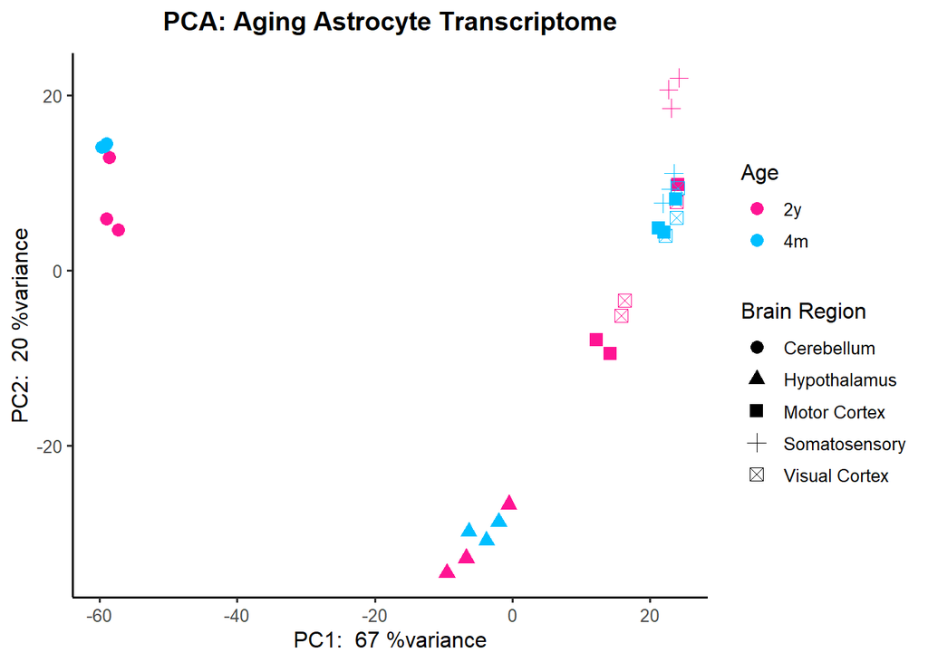

```r
pca
```

```r
#Code to calculate ellipses around data - not possible with this dataset due to low sample size per group
# pca + stat_ellipse(aes(group = metadata$Region),
#                                   type = "t",
#                                   linetype = 2,
#                                   lwd = 1)
```

### Heatmaps

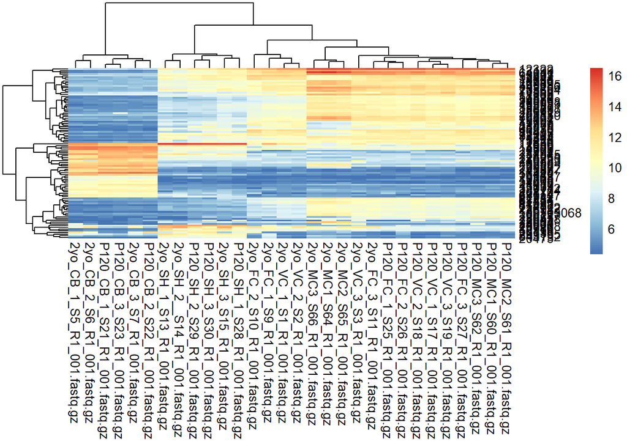

```r
#Example 1: Selecting most variable genes
topVarGenes <- head(order(-rowVars(assay(vsd))),100) # select top 100 most variable genes (across all samples)

pheatmap(assay(vsd)[topVarGenes,]) #basic heatmap
```

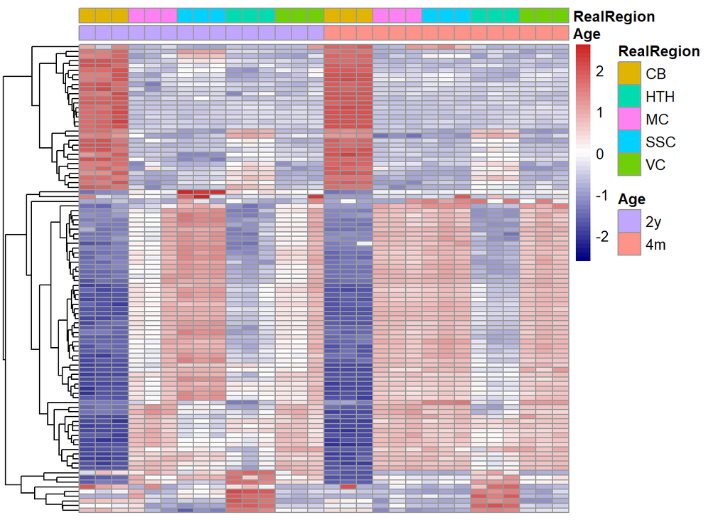

```r
sampleInfo <- as.data.frame(colData(dge)[,c("Age","RealRegion")]) #include annotations for plot based on metadata

map1 <- pheatmap(assay(vsd)[topVarGenes,],
           annotation_col = sampleInfo,
           scale = "row",
           color = colorRampPalette(c("navy", "white", "firebrick3"))(50),
           clustering_distance_rows = "euclidean",
           show_rownames = FALSE,
           show_colnames = FALSE,
           cluster_rows = TRUE,
           cluster_cols =  FALSE)
```

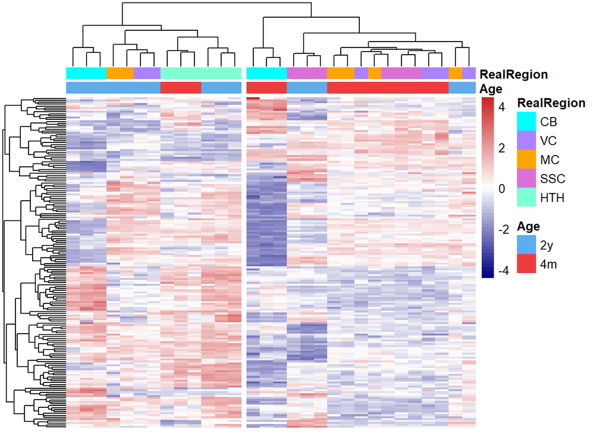

```r
#Example 2: Selecting significant DEGs for just Cerebellum 2y vs 4m
sigGenes <- subset(as.data.frame(res_CB), padj <=0.01)
sigGenes <- subset(sigGenes, abs(log2FoldChange) > 1)

#Create custom colors for your labels
my_colour = list(
  Age = c("2y" = "steelblue2", "4m" = "brown2"),
  RealRegion = c( CB = "cyan", VC = "mediumpurple1", MC = "orange1", SSC = "orchid", HTH = "aquamarine"))

map2 <- pheatmap(assay(vsd)[row.names(sigGenes),],
           annotation_col = sampleInfo,
           annotation_colors = my_colour,
           scale = "row",
           color = colorRampPalette(c("navy", "white", "firebrick3"))(50),
           clustering_distance_rows = "euclidean",
           show_rownames = FALSE,
           show_colnames = FALSE,
           cluster_rows = TRUE,
           cluster_cols =  TRUE,
           cutree_cols = 2)
```

```r
cluster <- as.data.frame(sort(cutree(map2$tree_row, k=3))) #Export clusters based on heatmap.
```

Another type of visualization option is to plot a heatmap of sample-to-sample distances. A heatmap of this distance matrix gives us an overview over similarities and dissimilarities between samples. We have to provide a hierarchical clustering hc to the heatmap function based on the sample distances, or else the heatmap function would calculate a clustering based on the distances between the rows/columns of the distance matrix.

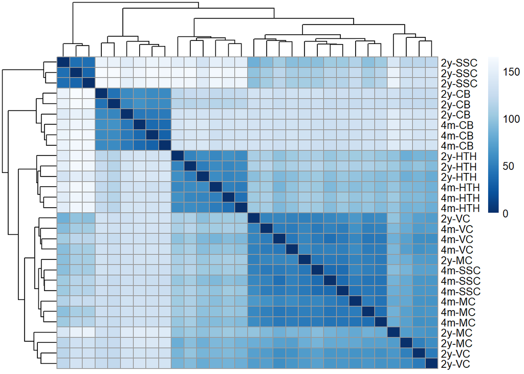

```r
sampleDists <- dist(t(assay(vsd)))
sampleDistMatrix <- as.matrix(sampleDists)
rownames(sampleDistMatrix) <- paste(vsd$Age, vsd$RealRegion, sep="-")
colnames(sampleDistMatrix) <- NULL
colors <- colorRampPalette( rev(brewer.pal(9, "Blues")) )(255)

pheatmap(sampleDistMatrix,
         clustering_distance_rows=sampleDists,
         clustering_distance_cols=sampleDists,
         col=colors)
```

### Volcano Plots

The plots below are made using [Enhanced Volcano package](https://www.bioconductor.org/packages/release/bioc/vignettes/EnhancedVolcano/inst/doc/EnhancedVolcano.html)

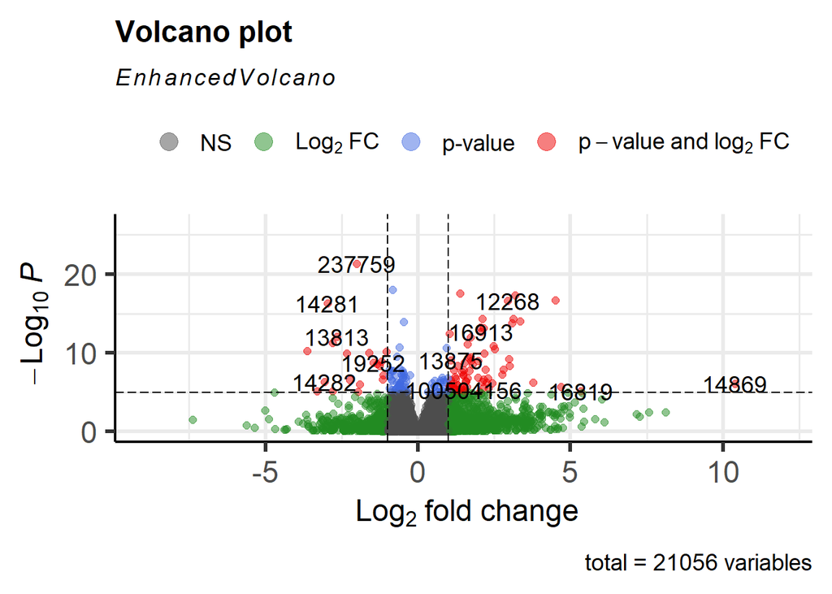

```r
EnhancedVolcano(res_CB,
    lab = rownames(res_CB),
    x = 'log2FoldChange',
    y = 'pvalue')
```

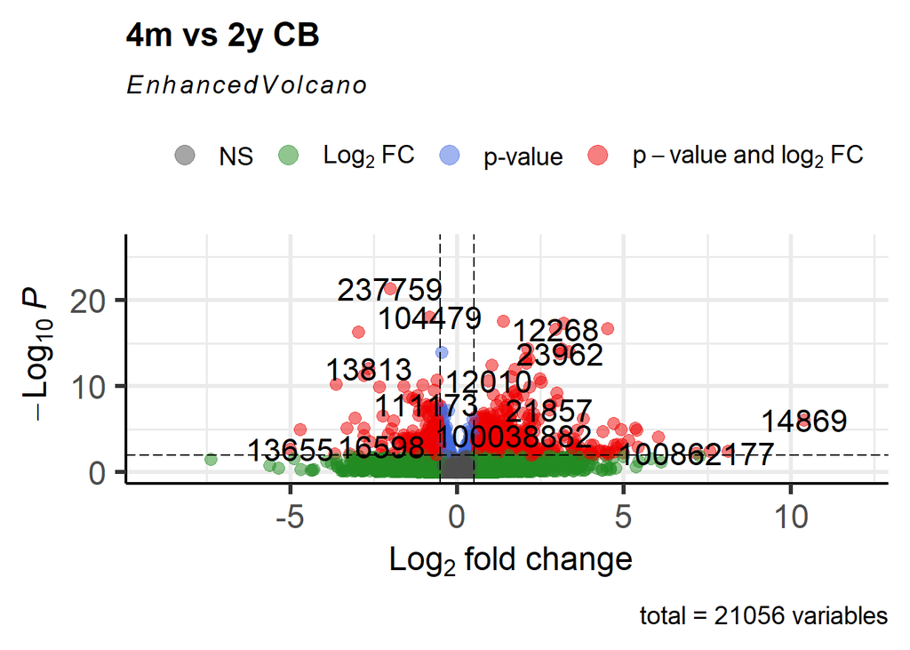

```r
EnhancedVolcano(res_CB,
    lab = rownames(res_CB),
    x = 'log2FoldChange',
    y = 'pvalue',
    title = '4m vs 2y CB',
    pCutoff = 0.01,
    FCcutoff = 0.5,
    pointSize = 3.0,
    labSize = 6.0)
```

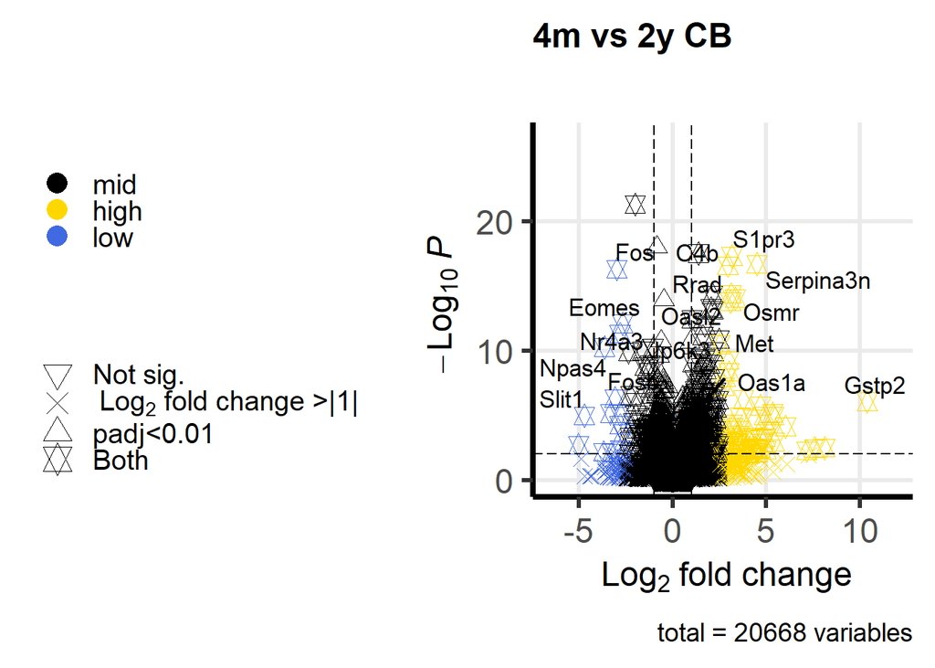

```r
#change row names to gene name instead of entrez ID
mart <- biomaRt::useDataset("mmusculus_gene_ensembl", useMart("ensembl")) #for default mouse genome

gene_list <- getBM(filters= "entrezgene_id",
                   attributes=c("entrezgene_id","mgi_symbol"),
                   values= rownames(res_CB),
                   mart= mart,
                   useCache = FALSE)

res_CB.df <- as.data.frame(res_CB)
res_CB.df <- merge(res_CB.df, gene_list, by.x = 0 , by.y = c("entrezgene_id"), all = TRUE)
res_CB.df <- res_CB.df[!is.na(res_CB.df$mgi_symbol),]

#Custom shape and color
keyvals <- ifelse(
           res_CB.df$log2FoldChange < -2.5, 'royalblue',
           ifelse(res_CB.df$log2FoldChange > 2.5, 'gold','black'))

keyvals[is.na(keyvals)] <- 'black'
names(keyvals)[keyvals == 'gold'] <- 'high'
names(keyvals)[keyvals == 'black'] <- 'mid'
names(keyvals)[keyvals == 'royalblue'] <- 'low'

Volcano1 <- EnhancedVolcano(res_CB.df,
            lab = res_CB.df$mgi_symbol,
            x = 'log2FoldChange',
            y = 'pvalue',
            selectLab = res_CB.df$mgi_symbol[which(names(keyvals) %in% c('high', 'low'))],
            xlab = bquote(~Log[2]~ 'fold change'),
            title = '4m vs 2y CB',
            subtitle = '',
            legendLabels=c('Not sig.',~Log[2]~ 'fold change >|1|','padj<0.01','Both'),
            pCutoff = 0.01,
            FCcutoff = 1.0,
            pointSize = 3.5,
            labSize = 4.5,
            shape = c(6, 4, 2, 11),
            colCustom = keyvals,
            colAlpha = 1,
            legendPosition = 'left',
            legendLabSize = 15,
            legendIconSize = 5.0,
            drawConnectors = TRUE,
            widthConnectors = 1.0,
            colConnectors = 'black',
            arrowheads = FALSE,
            gridlines.major = TRUE,
            gridlines.minor = FALSE,
            border = 'partial',
            borderWidth = 1.5,
            borderColour = 'black')


Volcano2 <- EnhancedVolcano(res_CB.df,
            lab = res_CB.df$mgi_symbol,
            x = "log2FoldChange",
            y = "pvalue",
            pCutoff = 0.01,
            FCcutoff = 1.5,
            pointSize = c(ifelse(res_CB.df$log2FoldChange>2, 2, 1)),
            labSize = 2.0,
            shape = c(6, 6, 19, 16),
            title = "DESeq2 results",
            subtitle = "Differential expression",
            caption = bquote(~Log[2]~ "fold change cutoff, 2; p-value cutoff, 0.01"),
            legendPosition = "right",
            legendLabSize = 14,
            legendLabels=c('Not sig.',~Log[2]~ 'fold change >|1|','padj<0.01','Both'),
            col = c("grey30", "forestgreen", "royalblue", "red2"),
            colAlpha = 0.9,
            drawConnectors = TRUE,
            hline = c(10e-8),
            widthConnectors = 0.5)

Volcano1
```

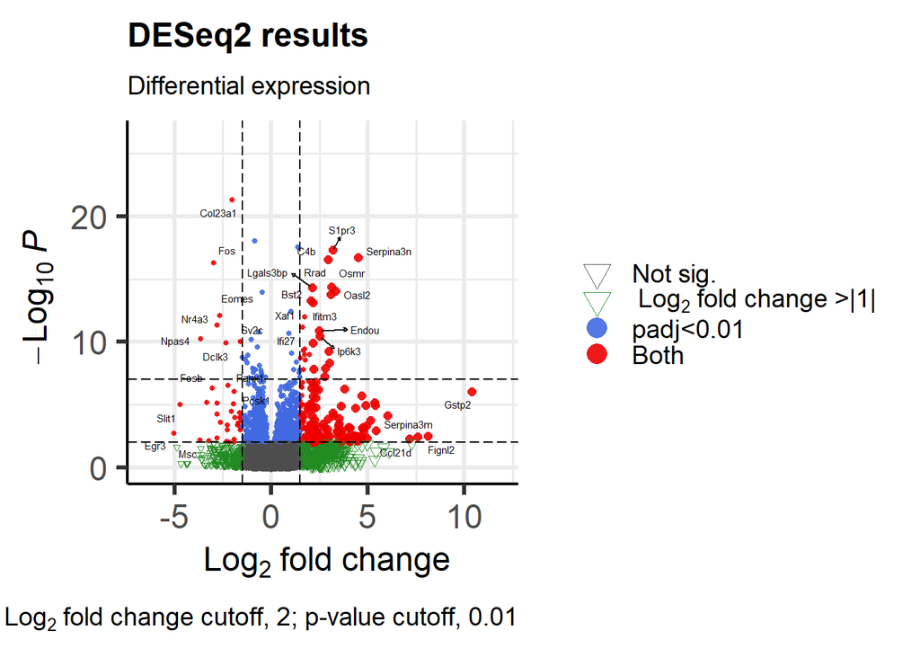

```r
Volcano2
```

### Plot Individual Counts

You can modify these plots with the usual ggplot2. Below is a just a basic example.

```r
d <- plotCounts(dds, gene=which.min(res_CB$padj), intgroup="AgeRegion",
                returnData=TRUE)
```

```
## using 'avgTxLength' from assays(dds), correcting for library size
```

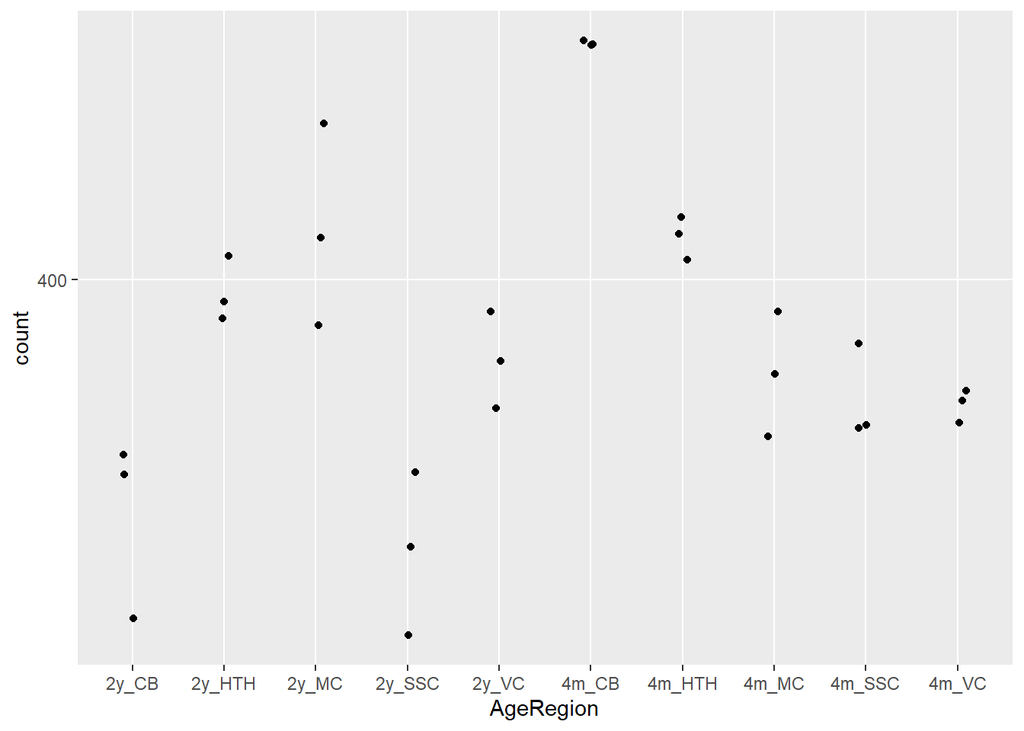

```r
ggplot(d, aes(x=AgeRegion, y=count)) +
  geom_point(position=position_jitter(w=0.1,h=0)) +
  scale_y_log10(breaks=c(25,100,400))
```

### DESeq2 Report Tool

This [function](https://www.rdocumentation.org/packages/regionReport/versions/1.6.5/topics/DESeq2Report) creates example graphs and tables with your data.

```r
dir.create("DESeq2Report-example", showWarnings = FALSE, recursive = TRUE)

## Generate the HTML report
report <- DESeq2Report(dge, "DESeq2-example", c("Age", "RealRegion"),
    outdir = "DESeq2Report-example"
)

if (interactive()) {
    ## Browse the report
    browseURL(report)
}
```

## Downstream Analyses

There are many options what to do next with your analyzed data. Some options and helpful links can be found below. **Note** This list is not exhaustive.

1. Online Tools
- [EnrichR](https://maayanlab.cloud/Enrichr/)
- [DAVID](https://david.ncifcrf.gov/)
- [Panther](http://www.pantherdb.org/)
- [Reactome](https://reactome.org/)
- [REVIGO](http://revigo.irb.hr/)
- [GSEA](https://www.gsea-msigdb.org/gsea/doc/GSEAUserGuideFrame.html)
- [String](https://string-db.org/)
2. Packages in R
- [ClusterProfiler](https://guangchuangyu.github.io/software/clusterProfiler/) - used below in example
- [fgsea](https://github.com/ctlab/fgsea#:~:text=fgsea%20is%20an%20R%2Dpackage,level%20split%20Monte%2DCarlo%20scheme.)
3. Other software
- [GSEA](https://www.gsea-msigdb.org/gsea/doc/GSEAUserGuideFrame.html)
- [Cytoscape](https://cytoscape.org/)

### Functional Enrichment (Overrepresentation Analysis - ORA)

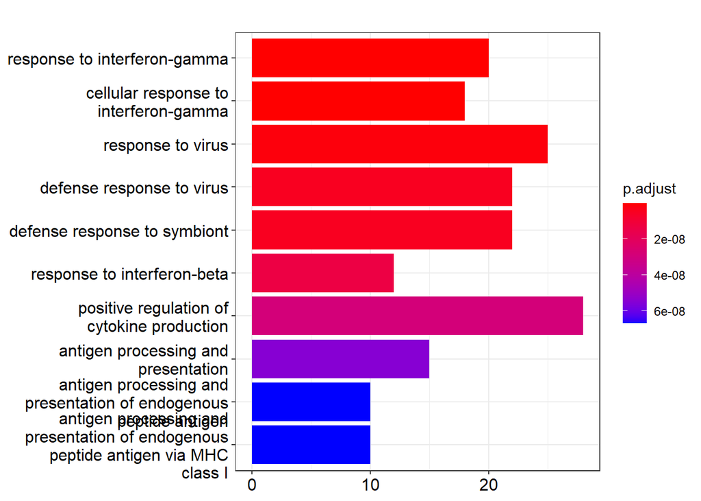

```r
#filter CB results for significant, upregulated genes only (adjusted pvalue of < 0.05; log2FC > 0.5)
res_CB_up <- res_CB.df[res_CB.df$log2FoldChange >= 0.5 & res_CB.df$padj <= 0.05, ]

ego_up <- enrichGO(gene    = res_CB_up$mgi_symbol,
                OrgDb         = org.Mm.eg.db,
                ont           = "ALL", #options are "ALL", "MF", "BP", "CC"
                keyType       = 'SYMBOL', #choose based on your gene list
                pvalueCutoff  = 0.05,
                readable      = FALSE)

ego_up.df <- as.data.frame(ego_up)

barplot(ego_up, showCategory=10)
```

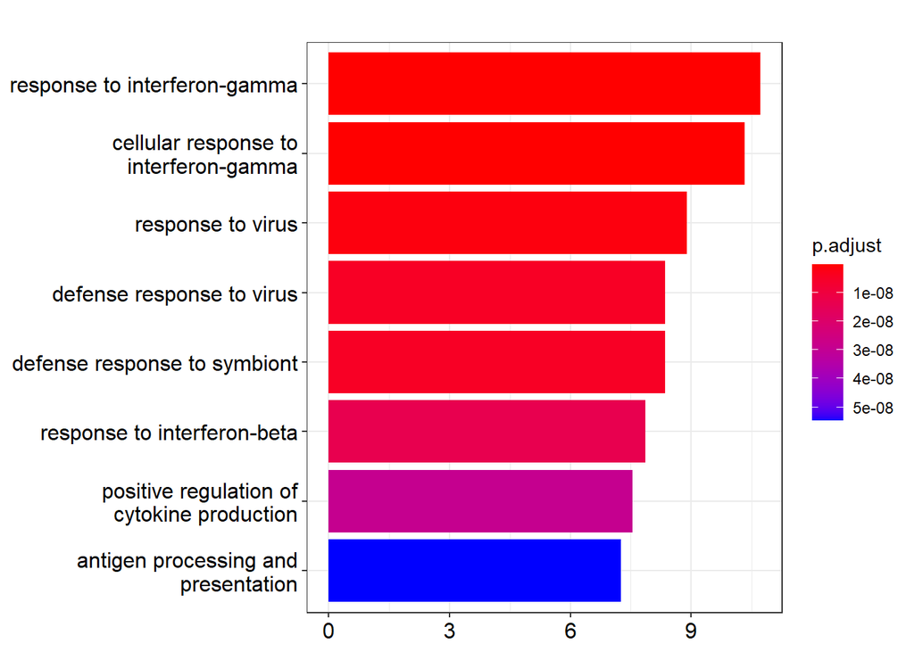

```r
#one way to change what is plotted
mutate(ego_up, qscore = -log(p.adjust, base=10)) %>%
    barplot(x="qscore")
```

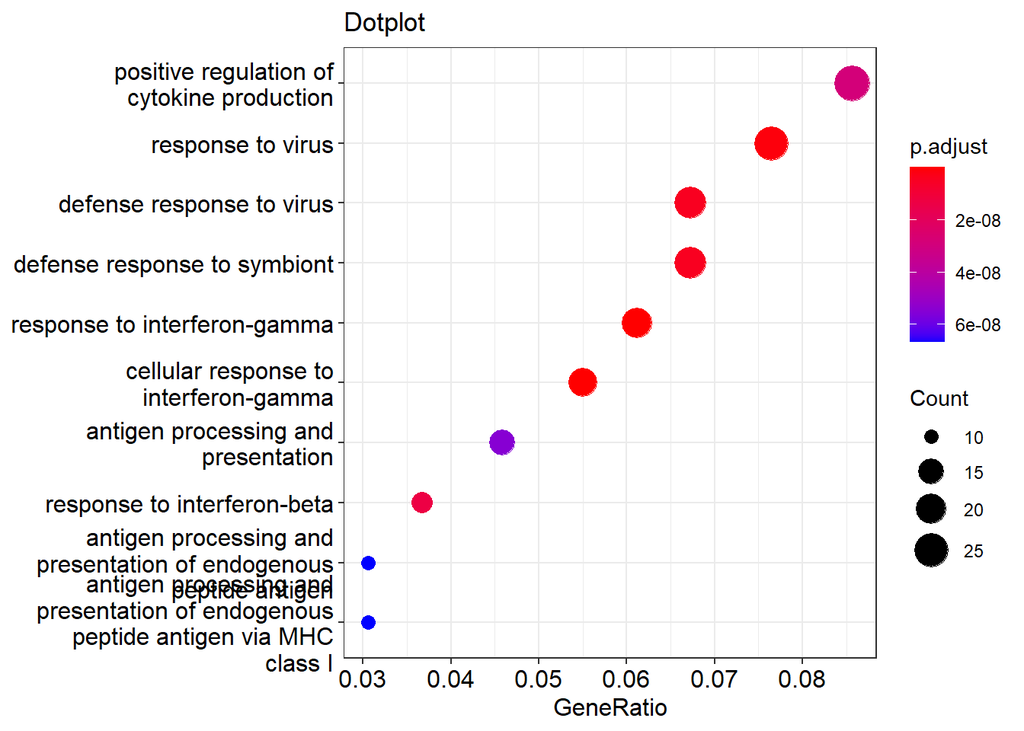

```r
dotplot(ego_up, showCategory=10) + ggtitle("Dotplot")
```

### Gene set enrichment analysis (GSEA)

```r
#select log2foldchange
res_CB_rnk <- res_CB.df[,3]
## feature 2: named vector
names(res_CB_rnk) <- as.character(res_CB.df[,8])
## feature 3: decreasing order
res_CB_rnk <- sort(res_CB_rnk, decreasing = TRUE)

#run gsea
gsea_res <- gseGO(geneList = res_CB_rnk,
              OrgDb        = org.Mm.eg.db,
              ont          = "MF",
              keyType      = 'SYMBOL',
              pvalueCutoff = 0.05,
              verbose      = TRUE)
```

```
## preparing geneSet collections...
```

```
## GSEA analysis...
```

```
## leading edge analysis...
```

```
## done...
```

```
## which will replace the existing scale.
```

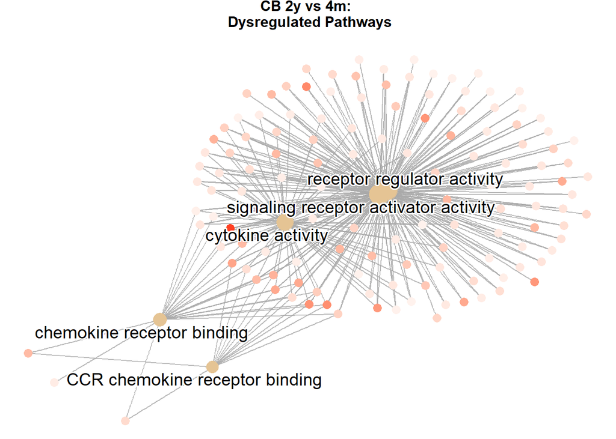

```r
#simplify results to remove redundant terms
gsea_res_sim <- simplify(gsea_res, cutoff=0.8, by="Description",
                         select_fun=min)

#visualizations
cnetplot(gsea_res, foldChange=res_CB_rnk, layout = 'kk',
         circular = FALSE, colorEdge = FALSE,
         categorySize="geneNum",
         cex_label = 0.5,
         cex_label_category = 1.0,
         node_label = "category",
         vertex.label.font=6) + guides(legend = "none") +
  scale_color_gradientn(name = "Fold Change",
                        colours = c("blue",
                                    "white","red"),
                        limits= c(-8, 8)) +
  theme(text=element_text(size=10),
        legend.position = "none",
        plot.title = element_text(hjust = 0.5, size=12, face="bold", margin = margin(0,0,10,0))) +
  ggtitle("CB 2y vs 4m: \n Dysregulated Pathways")
```

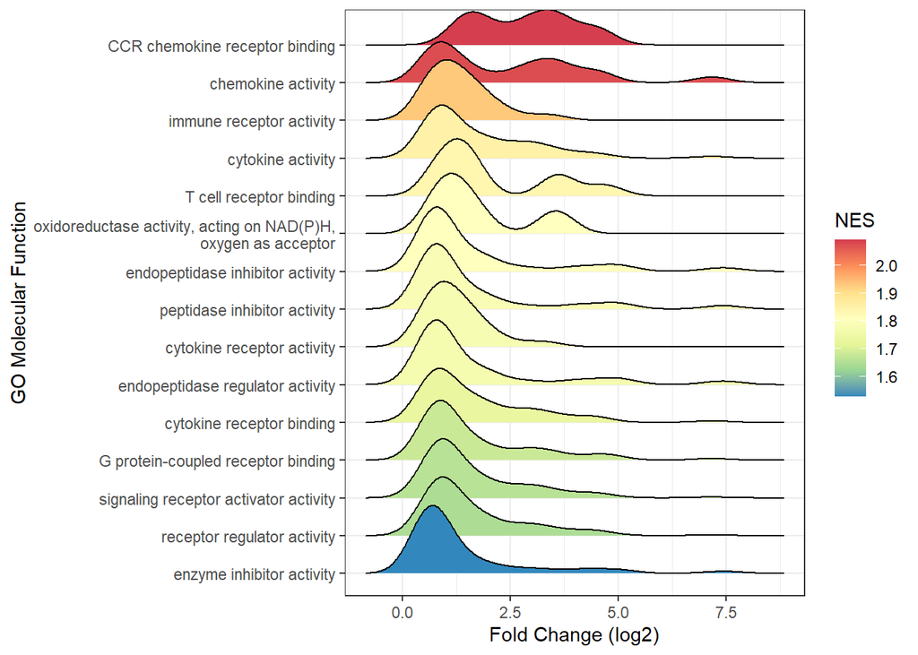

```r
r <- ridgeplot(gsea_res_sim, fill = 'NES', showCategory = 15,
               core_enrichment = TRUE,
               label_format = 50,
               orderBy = "NES") #density plots are generated by using the frequency
                                #of fold change values per gene within each set.

r + scale_fill_distiller(palette = "Spectral") +
  labs(x = "Fold Change (log2)", y = "GO Molecular Function") +
  theme_bw()
```

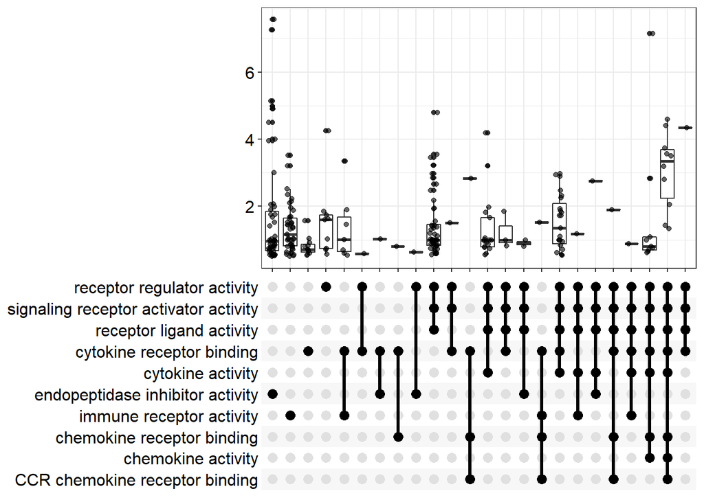

```r
upsetplot(gsea_res, label_format = 40)
```

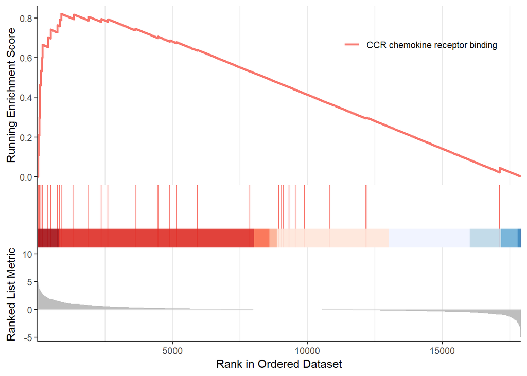

```r
gseaplot2(gsea_res, geneSetID = 1, pvalue_table = FALSE,
          color = c("#E495A5", "#86B875", "#7DB0DD"), ES_geom = "line")
```